# Homework 4

Chan Pok Wah

Before proceeding to solve the problems, make sure the `tidyverse` collection and the `maps` package is installed in your computer.

Note that some of the code blocks in this assignment contain the expression `eval = FALSE`. This tells R Markdown to display the code contained in the block, but not to evaluate it. Remove it if you want to turn off this behavior.

### Task 1: Plotting a choropleth map with `ggplot() + geom_map()`

The `maps` library has a variety of map datasets. Here we are going to use the dataset of the states of the United States mainland, named `state`, to create the reference map. It includes the latitute and longitude coordinates for the boundaries of the states.

```r
library(maps)
(states <- map_data("state") %>% as_tibble()) # Create a data frame holding the map data
```

```
## # A tibble: 15,537 x 6
##     long   lat group order region  subregion
##  * <dbl> <dbl> <dbl> <int> <chr>   <chr>
##  1 -87.5  30.4     1     1 alabama <NA>
##  2 -87.5  30.4     1     2 alabama <NA>
##  3 -87.5  30.4     1     3 alabama <NA>
##  4 -87.5  30.3     1     4 alabama <NA>
##  5 -87.6  30.3     1     5 alabama <NA>
##  6 -87.6  30.3     1     6 alabama <NA>
##  7 -87.6  30.3     1     7 alabama <NA>
##  8 -87.6  30.3     1     8 alabama <NA>
##  9 -87.7  30.3     1     9 alabama <NA>
## 10 -87.8  30.3     1    10 alabama <NA>
## # ... with 15,527 more rows
```

We are going to visualize state crime rates on the reference map. The `USArrests` dataset in base R contains this information, giving statistics, in arrests per 100,000 residents for assault, murder, and rape in each of the 50 US states in 1973.

```r
head(USArrests)
```

```
##            Murder Assault UrbanPop Rape
## Alabama      13.2     236       58 21.2
## Alaska       10.0     263       48 44.5
## Arizona       8.1     294       80 31.0
## Arkansas      8.8     190       50 19.5
## California    9.0     276       91 40.6
## Colorado      7.9     204       78 38.7
```

In this dataset, state names are stored as row names. In order to relate individual records to the map data, we need to convert the row name to a column named `region`. Row names of a regular data frame can be accessed using `row.names()`. Please also lowercase all state names in the resulting column (using `tolower()`):

```r
# Edit Here
USArrests$region <- tolower(row.names(USArrests))
head(USArrests)
```

```
##            Murder Assault UrbanPop Rape     region
## Alabama      13.2     236       58 21.2    alabama
## Alaska       10.0     263       48 44.5     alaska
## Arizona       8.1     294       80 31.0    arizona
## Arkansas      8.8     190       50 19.5   arkansas
## California    9.0     276       91 40.6 california
## Colorado      7.9     204       78 38.7   colorado
```

Now we are ready to create a choropleth map showing, for example, `Murder` rates using `ggplot() + geom_map()` (reference the **What’s More** section in the tutorial for **Geospatial Visualizatio**). You may want to change the legend position to top (`theme(legend.position = "top")`):

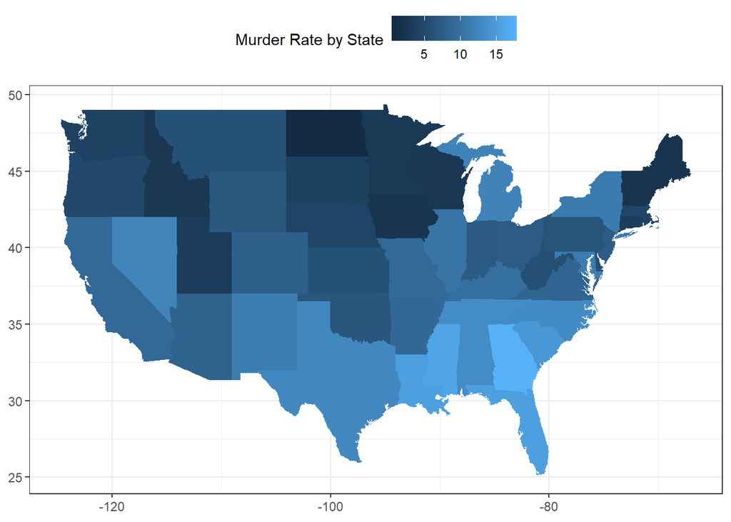

```r
# Edit Here
murder_by_state <- USArrests %>% right_join(states, by = 'region')
murder_by_state %>% ggplot(aes(fill = murder_by_state$Murder, map_id = region)) +
  geom_map(map = states) +
  expand_limits(x = states$long, y = states$lat) +
  scale_fill_gradient(name = "Murder Rate by State") +
  coord_fixed(1.4) +
  theme_bw() +
  theme(legend.position = "top",
        axis.title.x=element_blank(),
        axis.title.y=element_blank())
```

In the plot created above, it may be counter-intuitive that light blue (`"#56B1F7"`) indicates areas with high murder rates while dark blue (`"#132B43"`) indicates areas with low murder rates. Reverse the colour gradient using the `scale_fill_gradient()` and plot the revised choropleth map (`?scale_fill_gradient` if needed):

```r
str(scale_fill_gradient) # All we have to do is to swap the defaults for low and high
```

```
## function (..., low = "#132B43", high = "#56B1F7", space = "Lab", na.value = "grey50",
##     guide = "colourbar", aesthetics = "fill")
```

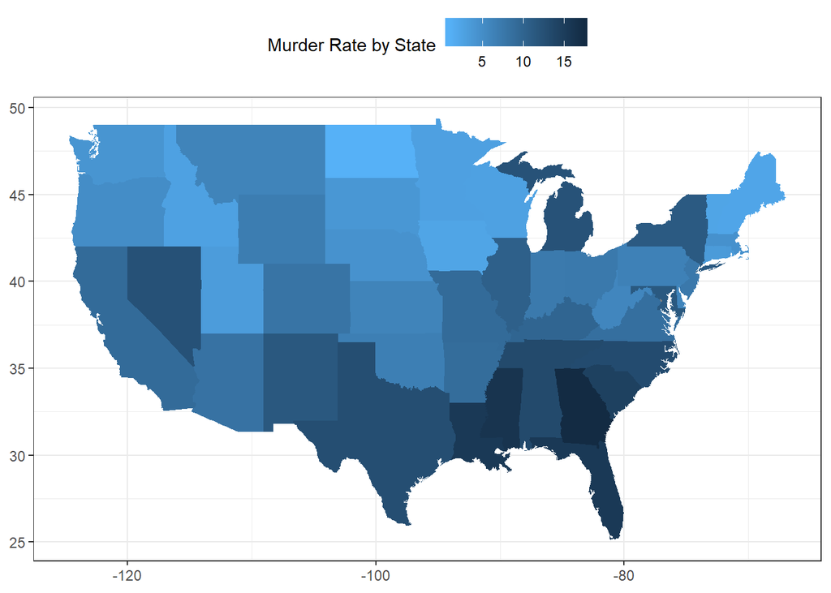

```r
# Edit Here
murder_by_state %>% ggplot(aes(fill = murder_by_state$Murder, map_id = region)) +
  geom_map(map = states) +
  expand_limits(x = states$long, y = states$lat) +
  scale_fill_gradient(low = '#56B1F7', high = '#132B43', name = "Murder Rate by State") +
  coord_fixed(1.4) +
  theme_bw() +
  theme(legend.position = "top",
        axis.title.x=element_blank(),
        axis.title.y=element_blank())
```

### Task 2: How Often Did Trump Mention His Competitors in the 2016 Presidential Campaign?

[FiveThirtyEight](http://fivethirtyeight.com/), a data journalism site devoted to politics, sports, science, economics, and culture, has published several articles based on analysing Trump’s tweets.

The article titled [*The World’s Favorite Donald Trump Tweets*](https://fivethirtyeight.com/features/the-worlds-favorite-donald-trump-tweets/) includes a figure showing the number of times Trump mentioned his primary competitors in the 2016 Presidential Campaign.

[figure not shown]

- `Tweet`: ids of a tweet;
- `Date`: the date the message got tweeted;
- `Candidate`: the candidate’s capitalised last name iif s/he was mentioned in the tweet. (`toupper()` can be used).

```r
twitter <- read_csv("data.csv")

twitter$Date <- strptime(twitter$Date, "%Y/%m/%d %H:%M")
twitter <- twitter[(twitter$Date >= strptime('2015/10/01', "%Y/%m/%d")) & (twitter$Date < strptime('2016/07/31', "%Y/%m/%d")),]

twitter$Candidate <- ""

twitter[(str_detect(twitter$`Text`, "John+") &
     str_detect(twitter$Text, "Kasich+")) |
    str_detect(twitter$Text, "@JohnKasich+"), "Candidate"] <- toupper("Kasich")
twitter[(str_detect(twitter$Text, "Jeb+") &
       str_detect(twitter$Text, "Bush+") |
       str_detect(twitter$Text, "@JebBush+")), "Candidate"] <- toupper("Bush")
twitter[(str_detect(twitter$Text, "Ted+") &
       str_detect(twitter$Text, "Cruz+") |
       str_detect(twitter$Text, "@tedcruz+")), "Candidate"] <- toupper("Cruz")
twitter[(str_detect(twitter$Text, "Hillary+") &
       str_detect(twitter$Text, "Clinton+") |
       str_detect(twitter$Text, "@HillaryClinton+")), "Candidate"] <- toupper("Clinton")
twitter[(str_detect(twitter$Text, "Marco+") &
       str_detect(twitter$Text, "Rubio+") |
       str_detect(twitter$Text, "@macrorubio+")), "Candidate"] <- toupper("Rubio")

options(scipen=999)
twitter$`Tweet ID` <- as.character(twitter$`Tweet ID`)
twitter$Date <- as.character(twitter$Date)
result <- twitter[twitter$Candidate != "" , c("Tweet ID", "Date", "Candidate")] %>% as.data.frame()
result
```

```
##               Tweet ID                Date Candidate
## 1   759450000000000000 2016-07-30 14:07:00   CLINTON
## 2   759372000000000000 2016-07-30 08:57:00   CLINTON
## 3   759191000000000000 2016-07-29 20:57:00   CLINTON
## 4   759085000000000000 2016-07-29 13:53:00   CLINTON
## 5   759071000000000000 2016-07-29 12:59:00   CLINTON
## 6   759022000000000000 2016-07-29 09:44:00   CLINTON
## 7   759008000000000000 2016-07-29 08:51:00   CLINTON
## 8   758874000000000000 2016-07-28 23:59:00   CLINTON
## 9   758872000000000000 2016-07-28 23:50:00   CLINTON
## 10  758335000000000000 2016-07-27 12:16:00   CLINTON
## 11  758285000000000000 2016-07-27 08:57:00      CRUZ
## 12  758243000000000000 2016-07-27 06:08:00   CLINTON
## 13  758135000000000000 2016-07-26 23:01:00   CLINTON
## 14  757777000000000000 2016-07-25 23:19:00   CLINTON
```

[output cut: 449 more lines]